# reesehs_FinalHomeworkCode_02

## Simulate 104 results from this distribution (i.e., 2 years of Saturday monitoring sessions).

```r
set.seed(1)#set up randomized sample set
Sat_mon <- rpois(104, 15)#number of samples, lambda(poisson stats have weird SDs so they don't include it in the ) and generates random numbers given the deviation
Sat_mon
```

```
##   [1] 12 20 19 16  9 16 17 17 13 20 16 12 13 13 15 11 18 17 18 18 15  7 16 19 12
##  [26] 13 16 20 14 16 14  9 18 13 19 13 21 17 13 11 12  8 17 14 18 16 12 11 20 22
##  [51] 13 10 10 24 14 17 15 12  9 20 15 23 16 12 14 17 19 15 14 11 12 19 17 14 13
##  [76] 13 18 13 19 17 20 11 19 17 21 17 10 15 18 18 11 11 10 21 17 18 16 21 12 15
## [101] 15  8 13 13
```

```r
#I initially was confusing myself by using the rnorm function but then I was asking Jimmy about what the standard deviation value would be for a poisson variable and he let me know that I should really be using rpois instead since the dataset is using poisson functions/data. So big thanks you to Jimmy!!
```

## Plot the simulated results using hist() and use xlim() to set the horizontal limits to be from 0 to 30. How does your histogram compare to the shape of the probability mass function you plotted above?

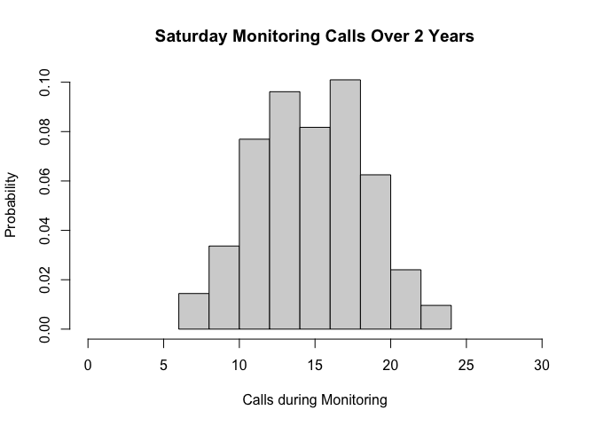

```r
hist(Sat_mon, xlim = c(0,30), probability = TRUE, main = "Saturday Monitoring Calls Over 2 Years",
    xlab = "Calls during Monitoring", ylab = "Probability") #creates histogram using randomized data from above question(Sat_Mon variable) and plots the probability of each value occurring. Graph has horizontal limits of 0-> 30(xlim is assigned to the range vector)
```

## Five Challenges faced

1. Initially I struggled with translating what was presented to me in the modules into something that could be used with poisson variables(given that we only had lambda and no other numbers) but once I was told by Jimmy and another class member that pois versions of the binomial functions that were used I was able to manipulate and figure out the problems pretty easily
2. The difference between dpois and ppois was a bit confusing to me before it was explained graphically. Understanding that ppois takes into account many points and dpois is used when looking at just one point was very helpful.
3. Finding the probability that there would be no calls threw me for a little bit of a loop because the number was small but when I looked at the histogram it became more clear why it would not be very probable that no calls would occur during the observation time.
4. As described in my comments above I was quite confused on how to create a randomized data set using poisson variables however, Jimmy was very nice and explained to me that(as far as I’m concerned) poisson has variance but standard deviation is very weird for it. I was trying to get the standard deviation for the data in order to get a randonmized set from rnorm. But like the rest of the functions rnorm has a poisson equivalent rpois, imagine that!
5. Figuring out how to use xlim was a little confusing. I didn’t realize that the range had to be inputted into a vector.

## Peer commentary from Sam

Great job!! Overall, your code and knitted file look great. Love the titi monkey picture. Everything is well annotated and I appreciated the fact that you included a link that explained how to get the cayman theme (something I initially had trouble with). Here are some more specific comments/suggestions I have below:  
1. Each question currently has a Header 1 format but I believe the homework prompt said to use a Header 2 prompt for each question! I would just add an extra hashtag to each section  
2. For the first question, why did you include the “lower = FALSE” argument? It would be helpful to include a comment addressing this!  
3. Not really a suggestion but I noticed that for question 2, you used dpois while I used ppois. Is there a particular reason you chose one over the other? I’ll have to go back to my own code to remember why I did what I did.